# PART 1 — Original Dataset EDA

First-pass exploration of the 6 core Epoch AI datasets: overview stats, ownership, the power/cost relationship, build-out timelines, and chip deployment volume.

## Setup + load

```python
import pandas as pd
import numpy as np
import matplotlib.pyplot as plt
import seaborn as sns

sns.set_theme(style="whitegrid")
pd.set_option("display.max_columns", 20)

dc = pd.read_csv("../data/processed/data_centers_clean.csv")
dc.shape
```

```
(74, 18)
```

## Overview

```python
dc.describe(include="all").T
```

|  | count | unique | top | freq | mean | std | min | 25% | 50% | 75% | max |
| --- | --- | --- | --- | --- | --- | --- | --- | --- | --- | --- | --- |
| name | 74 | 74 | Colossus 2 | 1 | NaN | NaN | NaN | NaN | NaN | NaN | NaN |
| current_h100_equivalents | 74.0 | NaN | NaN | NaN | 163240.6769 | 201654.163593 | 0.0 | 27665.48762 | 123799.898939 | 202753.916119 | 1111672.5619 |
| current_power_mw | 74.0 | NaN | NaN | NaN | 154.483784 | 186.199831 | 0.0 | 29.0 | 101.5 | 216.25 | 946.0 |
| current_total_capital_cost_2025_usd_billions | 74.0 | NaN | NaN | NaN | 5.852155 | 7.053622 | 0.0 | 1.098578 | 3.845023 | 8.191982 | 35.836372 |
| owner | 66 | 17 | Google #confident | 18 | NaN | NaN | NaN | NaN | NaN | NaN | NaN |
| users | 53 | 15 | Meta #confident | 13 | NaN | NaN | NaN | NaN | NaN | NaN | NaN |
| selected_sources | 74 | 74 | - [WSJ profile of the Colossus data centers](h... | 1 | NaN | NaN | NaN | NaN | NaN | NaN | NaN |
| calculations_sheet | 74 | 74 | https://docs.google.com/spreadsheets/d/1_FQATV... | 1 | NaN | NaN | NaN | NaN | NaN | NaN | NaN |
| project | 16 | 7 | Stargate #confident | 8 | NaN | NaN | NaN | NaN | NaN | NaN | NaN |
| current_chip_types | 50 | 22 | B300 | 10 | NaN | NaN | NaN | NaN | NaN | NaN | NaN |
| all_chip_types | 60 | 25 | B300 | 14 | NaN | NaN | NaN | NaN | NaN | NaN | NaN |
| investors | 7 | 5 | Google | 3 | NaN | NaN | NaN | NaN | NaN | NaN | NaN |
| construction_companies | 6 | 4 | Mortenson | 3 | NaN | NaN | NaN | NaN | NaN | NaN | NaN |
| energy_companies | 15 | 12 | Dominion Energy | 3 | NaN | NaN | NaN | NaN | NaN | NaN | NaN |
| country | 74 | 8 | United States | 65 | NaN | NaN | NaN | NaN | NaN | NaN | NaN |
| address | 64 | 63 | 5502 Spinks Rd, Abilene, TX 79601 | 2 | NaN | NaN | NaN | NaN | NaN | NaN | NaN |
| owner_name | 66 | 15 | Google | 19 | NaN | NaN | NaN | NaN | NaN | NaN | NaN |
| owner_confidence | 66 | 3 | confident | 63 | NaN | NaN | NaN | NaN | NaN | NaN | NaN |

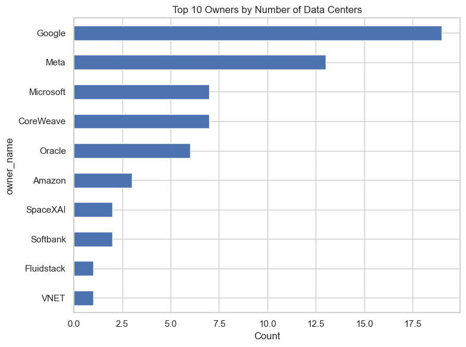

```python
dc = pd.read_csv("../data/processed/data_centers_clean.csv")

plt.figure(figsize=(8, 6))
dc["owner_name"].value_counts().head(10).plot(kind="barh")
plt.title("Top 10 Owners by Number of Data Centers")
plt.xlabel("Count")
plt.gca().invert_yaxis()
plt.tight_layout()
plt.show()
```

## Relationship between power and capital cost — do bigger (more power) data centers cost proportionally more?

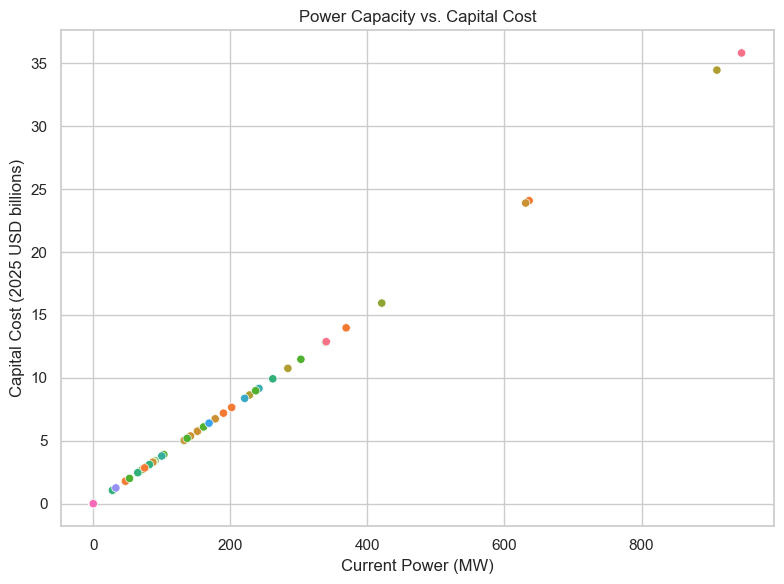

```python
plt.figure(figsize=(8, 6))
sns.scatterplot(data=dc, x="current_power_mw", y="current_total_capital_cost_2025_usd_billions",
                 hue="owner_name", legend=False)
plt.title("Power Capacity vs. Capital Cost")
plt.xlabel("Current Power (MW)")
plt.ylabel("Capital Cost (2025 USD billions)")
plt.tight_layout()
plt.show()
```

```python
correlation = dc["current_power_mw"].corr(dc["current_total_capital_cost_2025_usd_billions"])
print(f"Correlation: {correlation:.4f}")
```

```
Correlation: 1.0000
```

### Finding: Power and Capital Cost are not independent

Correlation = 1.0000. Capital cost appears to be derived directly from power capacity (likely `cost = power_mw × constant`), not independently reported. Treat these as one signal, not two, in any downstream analysis or dashboard — charting both separately would be redundant.

## Load and inspect timelines

```python
timelines = pd.read_csv("../data/processed/data_center_timelines_clean.csv", parse_dates=["date"])
timelines["date"].min(), timelines["date"].max()
```

```
(Timestamp('2018-12-18 00:00:00'), Timestamp('2030-01-01 00:00:00'))
```

### Power build-out for the top 5 data centers by current power

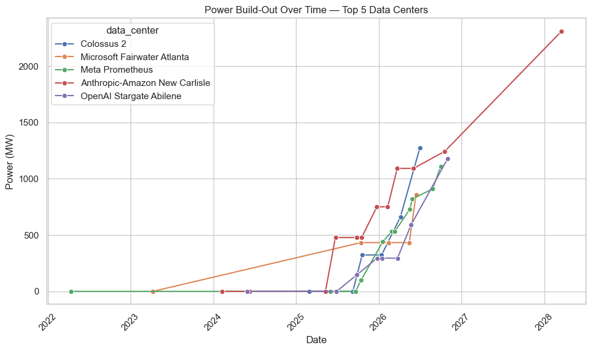

```python
top5_names = dc.sort_values("current_power_mw", ascending=False).head(5)["name"]
top5_timeline = timelines[timelines["data_center"].isin(top5_names)]

plt.figure(figsize=(10, 6))
sns.lineplot(data=top5_timeline, x="date", y="power_mw", hue="data_center", marker="o")
plt.title("Power Build-Out Over Time — Top 5 Data Centers")
plt.xlabel("Date")
plt.ylabel("Power (MW)")
plt.xticks(rotation=45)
plt.tight_layout()
plt.show()
```

## data_center_chip_quantities_clean.csv — it has actual unit counts per chip type per site, so we can see total deployed volume, not just which chip types are merely present somewhere.

```python
chips = pd.read_csv("../data/processed/data_center_chip_quantities_clean.csv")

chip_totals = chips.groupby("chip_type")["number_of_units"].sum().sort_values(ascending=False)
chip_totals.head(15)
```

```
chip_type
B200           8155868.0
Trainium2      7460346.0
B300           2657329.0
TPU v6e        1959538.0
TPU v5e        1857320.0
R200           1380550.0
H100           1112866.0
Ascend 910C     685699.0
TPU v5p         592137.0
H200            402394.0
A100            353187.0
H20             319817.0
R300            291671.0
TPU v4          194429.0
TPU v7          163123.0
Name: number_of_units, dtype: float64
```

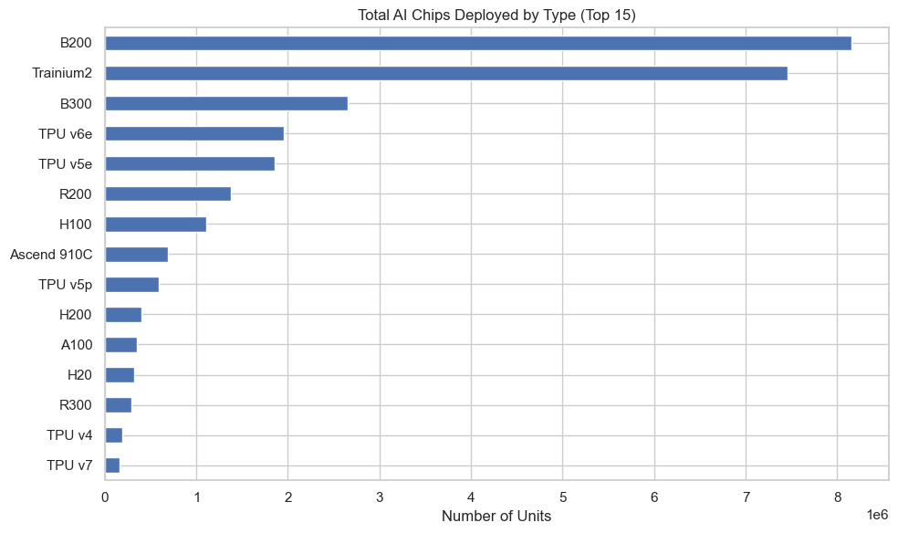

```python
plt.figure(figsize=(10, 6))
chip_totals.head(15).plot(kind="barh")
plt.title("Total AI Chips Deployed by Type (Top 15)")
plt.xlabel("Number of Units")
plt.ylabel("")
plt.gca().invert_yaxis()
plt.tight_layout()
plt.show()
```

### Finding: Chip deployment is led by NVIDIA Blackwell, but custom silicon is major

B200 (NVIDIA Blackwell) leads at ~8.2M units, but Amazon's Trainium2 (~7.5M) and Google's TPU family are close behind — custom/in-house accelerators make up a large share of total deployed compute, not just NVIDIA GPUs.

# PART 2 — Mining Previously-Unused Fields

Fields that existed in the source data from the start but were never analyzed: water use, energy efficiency by chip type, using the same 6 files as Part 1.

## Water use — data_center_timelines_clean.csv has a water_use_mgd column (million gallons/day) that hasn't been touched yet

```python
water = timelines[timelines["water_use_mgd"].notna()]
print(f"{len(water)} of {len(timelines)} timeline rows report water use ({(water['water_use_mgd']==0).sum()} are exactly 0)")
water.sort_values("water_use_mgd", ascending=False)[["data_center", "date", "power_mw", "water_use_mgd"]].head()
```

```
67 of 419 timeline rows report water use (57 are exactly 0)
```

|  | data_center | date | power_mw | water_use_mgd |
| --- | --- | --- | --- | --- |
| 167 | Meta Kuna | 2026-06-01 | 198.0 | 70000.00000 |
| 32 | Anthropic-Amazon New Carlisle | 2026-10-19 | 1244.0 | 21.00000 |
| 321 | Google Pryor (North) | 2024-07-19 | 63.0 | 2.28274 |
| 58 | Google New Albany | 2024-09-13 | 177.0 | 0.96600 |
| 57 | Google New Albany | 2024-04-20 | 81.0 | 0.84500 |

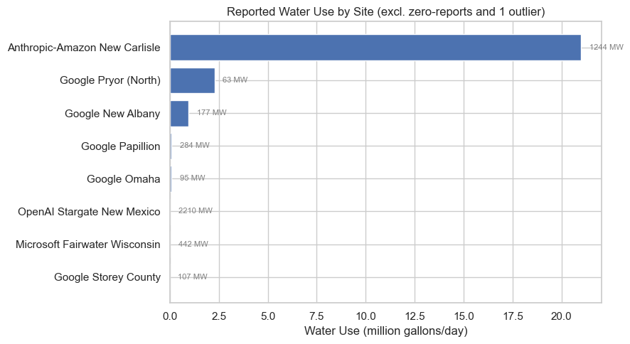

```python
# Meta Kuna reports 70,000 MGD at 198 MW — implausible (that's more than NYC's entire water supply
# for a single 198 MW site) and swamps the axis. Treating it as a data error and excluding it here.
# A ranked bar avoids the labeling overlap a scatter+annotate produces with this few, named points.
# Google New Albany reports twice (two build phases) — keep the latest so each site is one bar.
water_nonzero = water[(water["water_use_mgd"] > 0) & (water["data_center"] != "Meta Kuna")]
water_nonzero = water_nonzero.sort_values("date").drop_duplicates("data_center", keep="last")
water_bar = water_nonzero.sort_values("water_use_mgd")

plt.figure(figsize=(9, 5))
bars = plt.barh(water_bar["data_center"], water_bar["water_use_mgd"])
for bar, power in zip(bars, water_bar["power_mw"]):
    plt.text(bar.get_width() + water_bar["water_use_mgd"].max() * 0.02, bar.get_y() + bar.get_height() / 2,
              f"{power:.0f} MW", va="center", fontsize=8, color="gray")
plt.title("Reported Water Use by Site (excl. zero-reports and 1 outlier)")
plt.xlabel("Water Use (million gallons/day)")
plt.ylabel("")
plt.tight_layout()
plt.show()
```

### Finding: water use is too sparsely reported to support a sustainability comparison

Only 67 of 419 timeline rows report `water_use_mgd` at all, 57 of those are exactly 0 (air/closed-loop cooled, or simply not disclosed — the data doesn't distinguish), leaving just 9 usable non-zero data points plus one clear data error (Meta Kuna, 70,000 MGD at 198 MW, excluded above). No visible relationship to power capacity at this sample size. This field cannot support a "which data centers use less water" comparison as-is — it would need either more disclosure or a proxy (e.g. cooling system type from the chillers/cooling-towers tables) to be usable.

## Energy efficiency by chip type — gpu_clusters_clean.csv, unused so far

This file is a broader table of GPU clusters (482 rows) than `data_centers_clean.csv` (74 rows), and includes an `energy_efficiency` column plus per-site `latitude`/`longitude`.

```
406 of 482 clusters report energy_efficiency
```

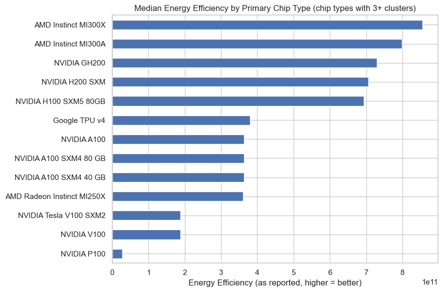

```python
gpu = pd.read_csv("../data/processed/gpu_clusters_clean.csv")
print(f"{gpu['energy_efficiency'].notna().sum()} of {len(gpu)} clusters report energy_efficiency")

eff_by_chip = (
    gpu[gpu["energy_efficiency"].notna()]
    .groupby("chip_type_primary")["energy_efficiency"]
    .agg(["median", "count"])
    .query("count >= 3")
    .sort_values("median", ascending=False)
)

plt.figure(figsize=(9, 6))
eff_by_chip["median"].plot(kind="barh")
plt.title("Median Energy Efficiency by Primary Chip Type (chip types with 3+ clusters)")
plt.xlabel("Energy Efficiency (as reported, higher = better)")
plt.ylabel("")
plt.gca().invert_yaxis()
plt.tight_layout()
plt.show()
```

# PART 3 — External Sustainability Data & the 10 Analytical Questions

From here on, this notebook pulls in an external dataset (OWID electricity data, cleaned in clean_data_centers.ipynb) to work through the 10 analytical questions from the project brief — country-level renewable share, carbon intensity, clustering, operator comparisons, and geographic concentration.

## Country sustainability & cost profile — joining in external data

None of the 6 source files contain electricity price, carbon emissions, or renewable-energy-% data — a real gap for the "where should AI data centers be built sustainably?" question this notebook works through below. Two external datasets close that gap, both cleaned in `clean_data_centers.ipynb`:

- **Sustainability**: [OWID's energy dataset](https://github.com/owid/energy-data) → `data/processed/owid_country_sustainability_clean.csv` (renewable share, carbon intensity, latest year per country)
- **Cost**: a manually compiled snapshot from [globalpetrolprices.com](https://www.globalpetrolprices.com/electricity_prices/) → `data/processed/electricity_price_clean.csv` (residential USD/kWh, 2023-2026 average — not a live feed, see caveat in the cleaning notebook)

Both join onto `gpu_clusters_clean.csv` by country.

```python
sustainability = pd.read_csv("../data/processed/owid_country_sustainability_clean.csv")

prices = pd.read_csv("../data/processed/electricity_price_clean.csv")

country_sustainability = (
    gpu.merge(sustainability[["country_epoch", "renewables_share_elec", "carbon_intensity_elec"]],
              left_on="country", right_on="country_epoch", how="left")
    .merge(prices[["country_epoch", "price_usd_per_kwh"]], left_on="country", right_on="country_epoch", how="left")
    .groupby("country")
    .agg(
        clusters=("name", "count"),
        total_power_mw=("power_capacity_mw", "sum"),
        renewables_share_elec=("renewables_share_elec", "first"),
        carbon_intensity_elec=("carbon_intensity_elec", "first"),
        price_usd_per_kwh=("price_usd_per_kwh", "first"),
    )
    .query("clusters >= 3")
    .sort_values("clusters", ascending=False)
)
country_sustainability
```

| country | clusters | total_power_mw | renewables_share_elec | carbon_intensity_elec | price_usd_per_kwh |
| --- | --- | --- | --- | --- | --- |
| China | 188 | 296.900000 | 37.044 | 525.34 | 0.076 |
| United States of America | 119 | 1962.754570 | 25.638 | 384.40 | 0.188 |
| Japan | 25 | 43.102966 | 23.569 | 477.26 | 0.227 |
| France | 14 | 33.175048 | 26.064 | 41.44 | 0.276 |
| Korea (Republic of) | 12 | 12.735673 | 10.394 | 417.06 | 0.127 |
| Germany | 11 | 25.171676 | 59.092 | 329.65 | 0.406 |
| Italy | 9 | 39.944208 | 48.776 | 284.78 | 0.414 |
| Brazil | 9 | 7.265970 | 86.601 | 109.95 | 0.164 |
| Russia | 8 | 5.720723 | 17.353 | 449.73 | 0.069 |
| United Kingdom of Great Britain and Northern Ireland | 6 | 11.996963 | 51.972 | 217.41 | 0.402 |
| Thailand | 5 | 3.464350 | 16.575 | 545.74 | 0.127 |
| Canada | 5 | 5.507334 | 63.900 | 190.72 | 0.123 |
| Switzerland | 4 | 26.777692 | 67.825 | 39.22 | 0.367 |
| Sweden | 4 | 7.432123 | 71.191 | 35.26 | 0.243 |
| Finland | 4 | 25.966398 | 56.464 | 57.47 | 0.175 |
| Poland | 4 | 1.787102 | 31.508 | 588.60 | 0.236 |
| India | 3 | 6.682458 | 24.067 | 670.13 | 0.077 |
| Australia | 3 | 1.890870 | 38.618 | 525.18 | 0.259 |
| Netherlands | 3 | 2.111549 | 51.200 | 253.56 | 0.286 |
| Norway | 3 | 29.222502 | 98.999 | 28.11 | 0.165 |
| Saudi Arabia | 3 | 14.181357 | 2.160 | 691.95 | 0.052 |
| Singapore | 3 | 1.978995 | 5.486 | 497.09 | 0.233 |
| Taiwan | 3 | 4.169312 | 12.240 | 633.21 | 0.098 |
| United Arab Emirates | 3 | 3.040491 | 8.812 | 467.51 | 0.080 |

## Q1 — Which countries host the largest concentration of AI-capable data centers? (Choropleth map)

Fills each country polygon by its GPU cluster count. Joins on ISO-3 code (`iso_code` from the OWID file / `ISO_A3` in the Natural Earth boundaries) rather than country name, since it's the more reliable key.

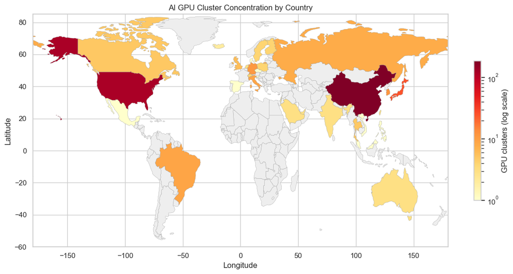

```python
import json
import matplotlib.colors as mcolors

with open("../data/raw/ne_110m_countries.geojson", encoding="utf-8") as f:
    world = json.load(f)

country_counts = gpu.groupby("country").size().reset_index(name="clusters")
country_counts = country_counts.merge(sustainability[["country_epoch", "iso_code"]],
                                       left_on="country", right_on="country_epoch", how="left")
count_by_iso = country_counts.set_index("iso_code")["clusters"]

cmap = plt.colormaps["YlOrRd"]
norm = mcolors.LogNorm(vmin=1, vmax=count_by_iso.max())

fig, ax = plt.subplots(figsize=(12, 6))
for feature in world["features"]:
    iso = feature["properties"].get("ISO_A3")
    count = count_by_iso.get(iso)
    color = cmap(norm(count)) if count and count > 0 else "#eeeeee"
    geom = feature["geometry"]
    polys = geom["coordinates"] if geom["type"] == "MultiPolygon" else [geom["coordinates"]]
    for poly in polys:
        xs, ys = zip(*poly[0])
        ax.fill(xs, ys, facecolor=color, edgecolor="#999999", linewidth=0.3)

sm = plt.cm.ScalarMappable(cmap=cmap, norm=norm)
sm.set_array([])
plt.colorbar(sm, ax=ax, label="GPU clusters (log scale)", shrink=0.6)
ax.set_xlim(-180, 180)
ax.set_ylim(-60, 85)
ax.set_title("AI GPU Cluster Concentration by Country")
ax.set_xlabel("Longitude")
ax.set_ylabel("Latitude")
plt.tight_layout()
plt.show()
```

## Q2 — Does cheaper electricity correlate with more data center capacity? (Scatter plot)

Using `price_usd_per_kwh` against each country's total GPU cluster power capacity (log scale — the US and China dominate so heavily that a linear axis hides everyone else).

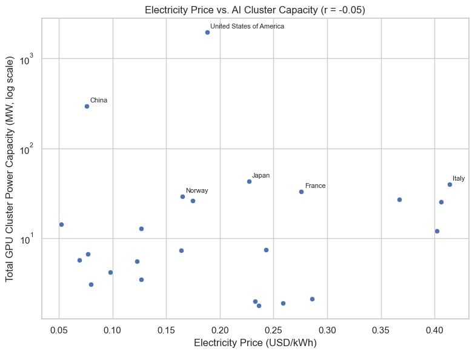

```python
plt.figure(figsize=(8, 6))
sns.scatterplot(data=country_sustainability, x="price_usd_per_kwh", y="total_power_mw")
plt.yscale("log")
for country in country_sustainability.nlargest(6, "total_power_mw").index:
    row = country_sustainability.loc[country]
    plt.annotate(country, (row["price_usd_per_kwh"], row["total_power_mw"]),
                  fontsize=8, xytext=(4, 4), textcoords="offset points")
r = country_sustainability["price_usd_per_kwh"].corr(country_sustainability["total_power_mw"])
plt.title(f"Electricity Price vs. AI Cluster Capacity (r = {r:.2f})")
plt.xlabel("Electricity Price (USD/kWh)")
plt.ylabel("Total GPU Cluster Power Capacity (MW, log scale)")
plt.tight_layout()
plt.show()
```

### Finding: no — cheaper electricity does not predict AI capacity

r = -0.05, essentially no linear relationship. China (0.076 USD/kWh) does have massive capacity, but the US (0.188 USD/kWh — pricier than Russia, India, Taiwan, Saudi Arabia, and South Korea, all far smaller AI hosts) still has 6-7x China's capacity. Whatever actually drives where AI infrastructure concentrates, it isn't raw electricity price — capital availability, existing cloud/tech ecosystems, chip supply access, and policy plausibly matter far more.

## Q3 — Which operators have the highest renewable energy adoption? (Bar chart)

Important caveat: we don't have each operator's actual clean-energy procurement (many hyperscalers buy PPAs/RECs that make their real usage cleaner than the local grid). This is a proxy — each operator's `owner_name` sites in `data_centers_clean.csv`, weighted by `current_power_mw`, mapped to the **grid's** renewable share in the country each site sits in. It measures "how clean is the grid where this operator builds," not "how clean is this operator."

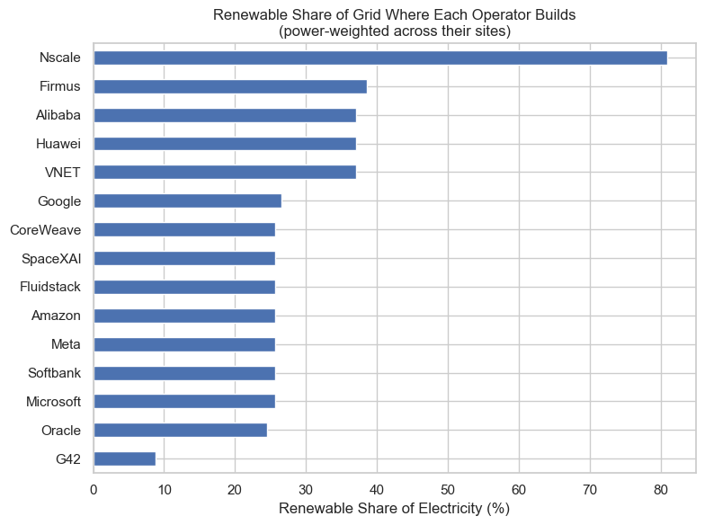

```python
dc_renew = dc.merge(sustainability[["country", "renewables_share_elec"]], on="country", how="left")

def weighted_or_mean(g):
    weights = g["current_power_mw"]
    if weights.sum() == 0:
        return g["renewables_share_elec"].mean()
    return np.average(g["renewables_share_elec"], weights=weights)

operator_renew = (
    dc_renew.groupby("owner_name")
    .apply(weighted_or_mean, include_groups=False)
    .rename("renewable_share_weighted")
    .sort_values(ascending=False)
)

plt.figure(figsize=(8, 6))
operator_renew.plot(kind="barh")
plt.title("Renewable Share of Grid Where Each Operator Builds\n(power-weighted across their sites)")
plt.xlabel("Renewable Share of Electricity (%)")
plt.ylabel("")
plt.gca().invert_yaxis()
plt.tight_layout()
plt.show()
```

### Finding: most major hyperscalers land in a tight band — a few single-site outliers stand apart

Nscale (~81%) is the clear outlier at the clean end (single European site), and G42 (~9%) at the dirty end. But the big names — Google, CoreWeave, SpaceXAI, Fluidstack, Amazon, Meta, Softbank, Microsoft, Oracle — all cluster tightly around 24-26%, because they're overwhelmingly US-sited and that's just the US grid average. This is grid cleanliness, not operator behavior — see the caveat above. A single-site operator's number says more about which one country they happen to be in than about any real efficiency difference.

## Q4 — How does carbon intensity differ across countries with major AI infrastructure? (Heatmap)

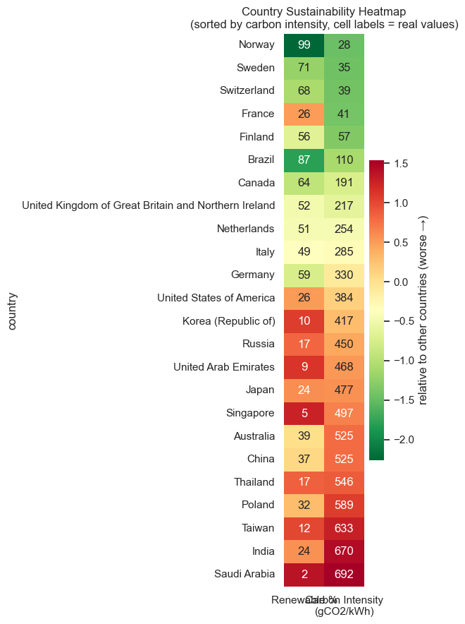

```python
heat_data = country_sustainability[["renewables_share_elec", "carbon_intensity_elec"]].sort_values("carbon_intensity_elec")

# Z-score each column so both share one color scale. Negate renewables_share_elec first
# so the colormap direction is consistent: red = bad (high carbon / low renewable) for both.
heat_color = (heat_data - heat_data.mean()) / heat_data.std()
heat_color["renewables_share_elec"] *= -1

plt.figure(figsize=(6, 9))
sns.heatmap(heat_color, annot=heat_data.round(0), fmt=".0f", cmap="RdYlGn_r",
            cbar_kws={"label": "relative to other countries (worse →)"},
            xticklabels=["Renewable %", "Carbon Intensity\n(gCO2/kWh)"])
plt.title("Country Sustainability Heatmap\n(sorted by carbon intensity, cell labels = real values)")
plt.tight_layout()
plt.show()
```

### Finding: a 24x spread between the cleanest and dirtiest grids in this set

Norway sits at 28 gCO2/kWh; Saudi Arabia at 692 gCO2/kWh — both host meaningful AI infrastructure today. Countries hosting AI clusters span nearly the entire global range of grid cleanliness; there's no cluster of infrastructure only in clean grids or only in dirty ones.

## Q5 — Which countries provide the best balance of electricity cost and sustainability? (Bubble chart)

Composite of 3 z-scored signals — cheap electricity, high renewable share, low carbon intensity — averaged into one score. Bubble size = number of GPU clusters (today's activity level, shown for reference; the score itself isn't weighted by it).

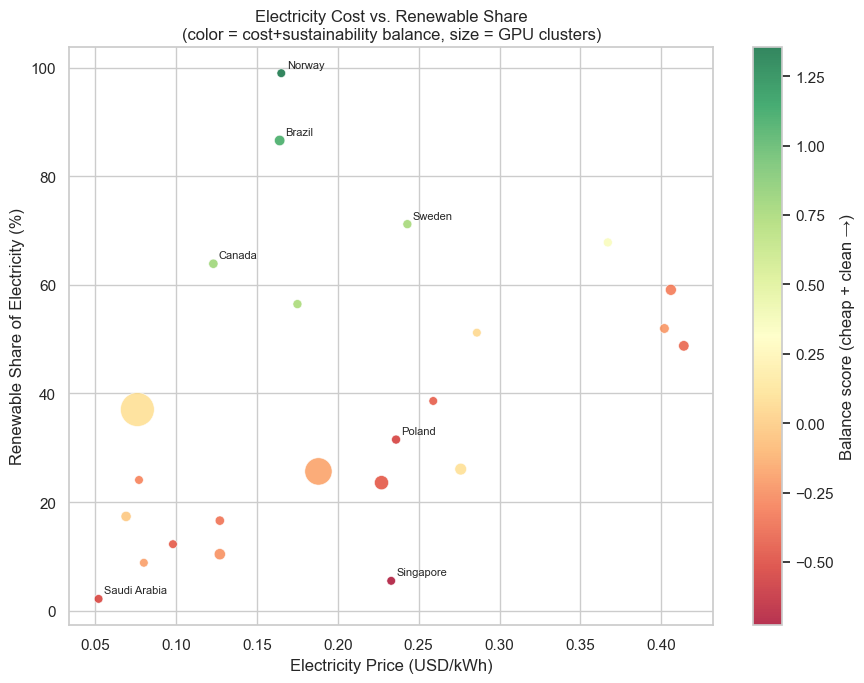

```python
z = lambda s: (s - s.mean()) / s.std()
country_sustainability["balance_score"] = (
    -z(country_sustainability["price_usd_per_kwh"])
    + z(country_sustainability["renewables_share_elec"])
    - z(country_sustainability["carbon_intensity_elec"])
) / 3

plt.figure(figsize=(9, 7))
sc = plt.scatter(country_sustainability["price_usd_per_kwh"], country_sustainability["renewables_share_elec"],
                  s=country_sustainability["clusters"] * 3 + 30, c=country_sustainability["balance_score"],
                  cmap="RdYlGn", alpha=0.8, edgecolor="white", linewidth=0.5)
standouts = pd.concat([country_sustainability["balance_score"].nlargest(4),
                       country_sustainability["balance_score"].nsmallest(3)]).index
for country in standouts:
    row = country_sustainability.loc[country]
    plt.annotate(country, (row["price_usd_per_kwh"], row["renewables_share_elec"]),
                  fontsize=8, xytext=(4, 4), textcoords="offset points")
plt.colorbar(sc, label="Balance score (cheap + clean →)")
plt.title("Electricity Cost vs. Renewable Share\n(color = cost+sustainability balance, size = GPU clusters)")
plt.xlabel("Electricity Price (USD/kWh)")
plt.ylabel("Renewable Share of Electricity (%)")
plt.tight_layout()
plt.show()
```

### Finding: Norway and Brazil lead; China's cost advantage changes its ranking

Norway (cheap + 99% renewable) and Brazil (cheap + 87% renewable) top the composite. China is notably higher here than in the sustainability-only view (Q4/Q8/Q10) because it's genuinely cheap (0.076 USD/kWh) even though its grid isn't especially clean — cost and sustainability don't reward the same countries. The US ranks below average on this composite (mid-pack sustainability, above-average price) despite hosting the most capacity by far — today's build-out pattern doesn't track this balance score.

## Q6 — Where are new AI data centers being built most rapidly? (Timeline)

Uses `data_center_timelines_clean.csv` — each data center's earliest tracked date as its "project start," grouped by year and country. Note this table only covers the 74 sites in `data_centers_clean.csv` (Epoch's curated large/notable set), which is heavily US-weighted — treat the country split as directional, not representative of global build activity the way `gpu_clusters_clean.csv` is elsewhere in this notebook.

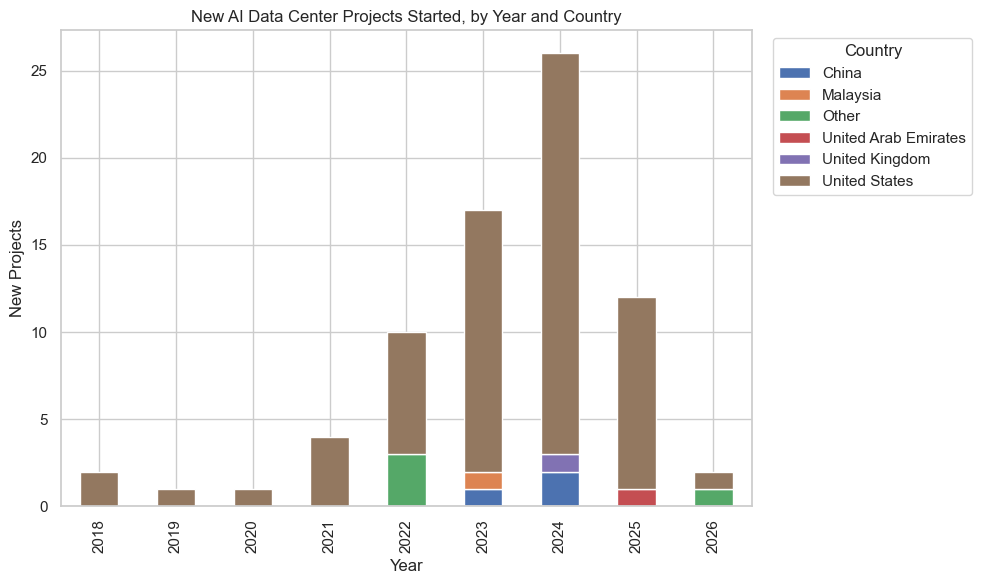

```python
first_seen = (
    timelines.merge(dc[["name", "country"]], left_on="data_center", right_on="name", how="left")
    .groupby("data_center")
    .agg(country=("country", "first"), start_date=("date", "min"))
)
first_seen["start_year"] = first_seen["start_date"].dt.year

top_countries = first_seen["country"].value_counts().head(5).index
first_seen["country_grouped"] = first_seen["country"].where(first_seen["country"].isin(top_countries), "Other")

by_year_country = first_seen.groupby(["start_year", "country_grouped"]).size().unstack(fill_value=0)

by_year_country.plot(kind="bar", stacked=True, figsize=(10, 6))
plt.title("New AI Data Center Projects Started, by Year and Country")
plt.xlabel("Year")
plt.ylabel("New Projects")
plt.legend(title="Country", bbox_to_anchor=(1.02, 1), loc="upper left")
plt.tight_layout()
plt.show()
```

### Finding: 2024 was the peak year, and it's overwhelmingly a US story

26 new tracked projects started in 2024 (up from 10 in 2022, 17 in 2023) before dropping to 12 in 2025 — more than half of all 74 tracked projects started in 2023-2024 alone, and the United States accounts for the large majority of every year's total. Remember the caveat above: this table only covers Epoch's curated 74-site set, not the broader global picture from `gpu_clusters_clean.csv`.

## Q7 — How does renewable energy usage relate to estimated emissions? (Scatter plot with regression)

Using `carbon_intensity_elec` as the emissions measure (grams CO2 per kWh actually generated, rather than a country total, which would just track population/economy size instead of grid cleanliness).

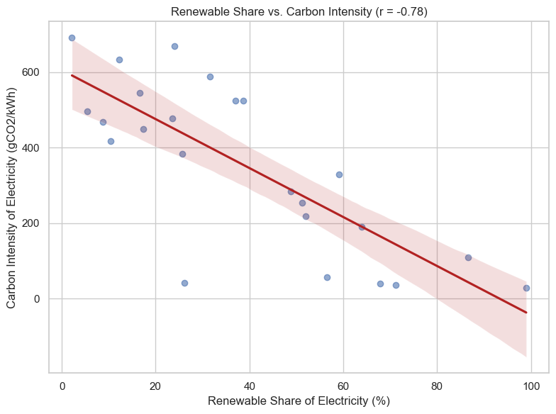

```python
plt.figure(figsize=(8, 6))
sns.regplot(data=country_sustainability, x="renewables_share_elec", y="carbon_intensity_elec",
            scatter_kws={"alpha": 0.6}, line_kws={"color": "firebrick"})
r = country_sustainability["renewables_share_elec"].corr(country_sustainability["carbon_intensity_elec"])
plt.title(f"Renewable Share vs. Carbon Intensity (r = {r:.2f})")
plt.xlabel("Renewable Share of Electricity (%)")
plt.ylabel("Carbon Intensity of Electricity (gCO2/kWh)")
plt.tight_layout()
plt.show()
```

## Q8 — Which regions are best suited for future AI expansion? (Ranking)

A composite score isn't in the source data — built here as the average of two z-scored signals: renewable share (higher better) and carbon intensity (lower better). This says nothing about land, grid capacity headroom, or policy — just "how clean is this country's electricity today."

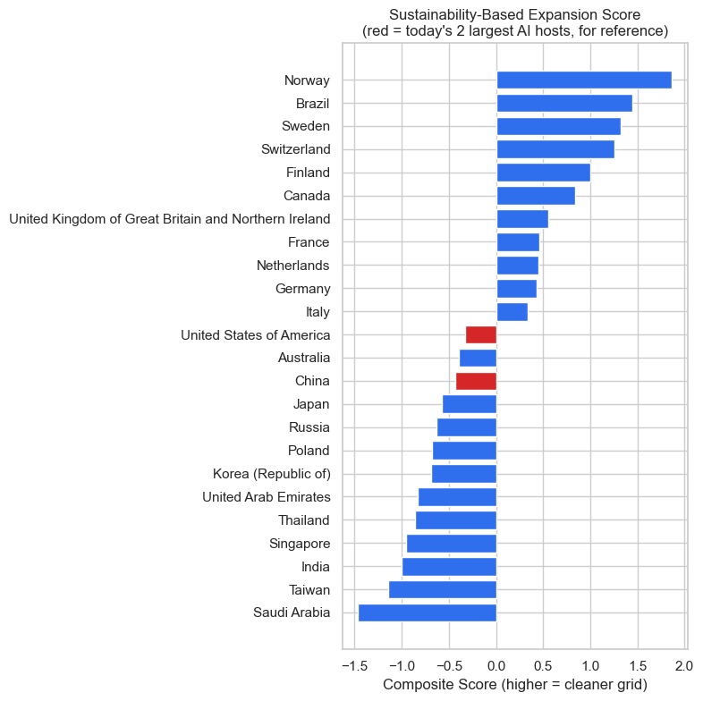

```python
z_renew = (country_sustainability["renewables_share_elec"] - country_sustainability["renewables_share_elec"].mean()) / country_sustainability["renewables_share_elec"].std()
z_carbon = (country_sustainability["carbon_intensity_elec"] - country_sustainability["carbon_intensity_elec"].mean()) / country_sustainability["carbon_intensity_elec"].std()
expansion_score = ((z_renew - z_carbon) / 2).sort_values(ascending=False)

colors = ["#d62728" if c in ("United States of America", "China") else "#2f6fed" for c in expansion_score.index]
plt.figure(figsize=(8, 8))
plt.barh(expansion_score.index, expansion_score.values, color=colors)
plt.title("Sustainability-Based Expansion Score\n(red = today's 2 largest AI hosts, for reference)")
plt.xlabel("Composite Score (higher = cleaner grid)")
plt.gca().invert_yaxis()
plt.tight_layout()
plt.show()
```

### Finding: Norway, Brazil, and Sweden top a sustainability-only ranking; Saudi Arabia bottom

This ranking ignores cost entirely (see Q5 for the cost-adjusted version, which reorders things — China rises once cost is factored in). Both today's largest hosts, the US and China, sit in the lower half on sustainability alone.

## Q9 — How do cloud providers compare in global infrastructure footprint? (Treemap)

Using `gpu_clusters_clean.csv`'s `owner` field (broader coverage than `data_centers_clean.csv`), summed power capacity by owner. 198 of 482 clusters have no reported owner and are excluded.

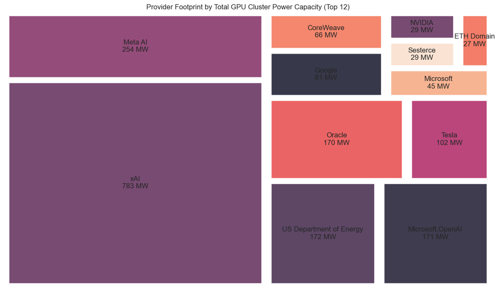

```python
import squarify

owner_power = gpu.dropna(subset=["owner"]).groupby("owner")["power_capacity_mw"].sum().sort_values(ascending=False).head(12)

plt.figure(figsize=(12, 7))
squarify.plot(sizes=owner_power.values, label=[f"{o}\n{p:.0f} MW" for o, p in owner_power.items()],
              alpha=0.8, pad=True)
plt.title("Provider Footprint by Total GPU Cluster Power Capacity (Top 12)")
plt.axis("off")
plt.tight_layout()
plt.show()
```

### Finding: xAI's single build dwarfs every hyperscaler's entire footprint

xAI alone (783 MW, largely its Colossus site) exceeds Meta AI + CoreWeave + Google + Microsoft + Oracle combined (254 + 66 + 81 + 45 + 170 = 616 MW). A single concentrated build can outweigh several large, diversified providers at once.

## Q10 — Can countries be grouped into AI infrastructure profiles based on energy, emissions, and capacity? (K-Means cluster plot)

Grouping the same 24 countries on 4 features: `renewables_share_elec`, `carbon_intensity_elec`, log(`total_power_mw`), log(`clusters`) — standardized, then K-Means. Tried k=2..6 and picked by silhouette score.

```python
from sklearn.preprocessing import StandardScaler
from sklearn.cluster import KMeans
from sklearn.metrics import silhouette_score

features = country_sustainability[["renewables_share_elec", "carbon_intensity_elec", "total_power_mw", "clusters"]].copy()
features["total_power_mw"] = np.log1p(features["total_power_mw"])
features["clusters"] = np.log1p(features["clusters"])
X_scaled = StandardScaler().fit_transform(features)

for k in range(2, 7):
    labels = KMeans(n_clusters=k, n_init=10, random_state=0).fit_predict(X_scaled)
    print(f"k={k}  silhouette={silhouette_score(X_scaled, labels):.3f}")

kmeans = KMeans(n_clusters=3, n_init=10, random_state=0).fit(X_scaled)
country_sustainability["cluster"] = kmeans.labels_
country_sustainability.groupby("cluster").agg(
    n_countries=("clusters", "size"),
    avg_renewables_share_elec=("renewables_share_elec", "mean"),
    avg_carbon_intensity_elec=("carbon_intensity_elec", "mean"),
    total_power_mw=("total_power_mw", "sum"),
).round(1)
```

```
k=2  silhouette=0.385
k=3  silhouette=0.502
k=4  silhouette=0.415
k=5  silhouette=0.348
```

```
k=6  silhouette=0.328
```

| cluster | n_countries | avg_renewables_share_elec | avg_carbon_intensity_elec | total_power_mw |
| --- | --- | --- | --- | --- |
| 0 | 11 | 62.0 | 144.3 | 214.6 |
| 1 | 11 | 17.3 | 542.1 | 98.8 |
| 2 | 2 | 31.3 | 454.9 | 2259.7 |

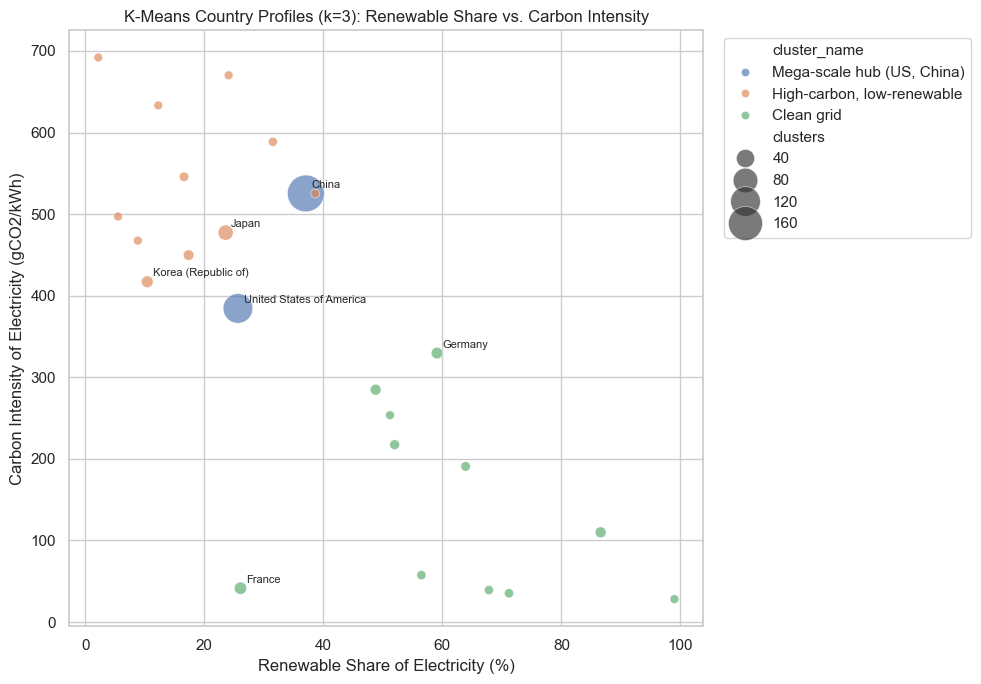

```python
# Name clusters from their own stats rather than hardcoding cluster IDs — KMeans label
# numbering (0/1/2) is arbitrary and isn't guaranteed to match across runs.
cluster_stats = country_sustainability.groupby("cluster")[["renewables_share_elec", "total_power_mw"]].mean()
mega_scale_id = cluster_stats["total_power_mw"].idxmax()
remaining = cluster_stats.drop(mega_scale_id)
clean_id = remaining["renewables_share_elec"].idxmax()
dirty_id = remaining["renewables_share_elec"].idxmin()
cluster_names = {mega_scale_id: "Mega-scale hub (US, China)", clean_id: "Clean grid", dirty_id: "High-carbon, low-renewable"}
country_sustainability["cluster_name"] = country_sustainability["cluster"].map(cluster_names)

plt.figure(figsize=(10, 7))
sns.scatterplot(
    data=country_sustainability, x="renewables_share_elec", y="carbon_intensity_elec",
    hue="cluster_name", size="clusters", sizes=(40, 700), alpha=0.65,
)
for country, row in country_sustainability.iterrows():
    if row["cluster"] == mega_scale_id or row["clusters"] >= 10:
        plt.annotate(country, (row["renewables_share_elec"], row["carbon_intensity_elec"]),
                      fontsize=8, xytext=(4, 4), textcoords="offset points")
plt.title("K-Means Country Profiles (k=3): Renewable Share vs. Carbon Intensity")
plt.xlabel("Renewable Share of Electricity (%)")
plt.ylabel("Carbon Intensity of Electricity (gCO2/kWh)")
plt.legend(bbox_to_anchor=(1.02, 1), loc="upper left")
plt.tight_layout()
plt.show()
```

### Finding: scale, not sustainability, is what actually separates countries

k=3 gave the best silhouette score (0.502) of the range tested, and the resulting groups are easy to name:

- **Mega-scale hub** — just US and China. They separate from everyone else almost entirely on raw scale (2,260 MW combined vs. ~100-215 MW for the other two groups), not on their sustainability numbers, which are mid-pack (26-37% renewable, 384-525 gCO₂/kWh).
- **Clean grid** (11 countries: Norway, Sweden, Switzerland, France, Finland, Brazil, Canada, UK, Netherlands, Italy, Germany) — avg 62% renewable, avg 144 gCO₂/kWh.
- **High-carbon, low-renewable** (11 countries: South Korea, Russia, UAE, Japan, Singapore, Australia, Thailand, Poland, Taiwan, India, Saudi Arabia) — avg 17% renewable, avg 542 gCO₂/kWh.